# EDA_FE_CTR

Task 5

This task is about displaying advertising banners on web sites. It’s needed to show a proper adv, impression act. The success criterion is maximized CTR (clickthrough rate) when the number of the placeholders are limited, e.g., vacant banners in web sites. Could you please design and create a recommender system that could help in this case? Please, could you reflect on the response time, since it could be an important requirement. Historical data for several days is posted here[1].

We propose to use Vowpal Wabbit[2]. There are few realizations: PyPpark package[3], bare python library, console application, and API. In case of lack of computing resources, use sampling. Exploratory data analysis is the assessed part of the assignment.

Success criteria A method for estimating the show cost is proposed Demonstrated the benefits of using Behavior insights presented; client segments proposed The solution works in high loaded and parallel mode

[1] https://www.kaggle.com/c/avazu-ctr-prediction/data

[2] https://vowpalwabbit.org/

[3] https://github.com/Azure/mmlspark/blob/master/docs/vw.md

# Imports

```python
!pip install vowpalwabbit
```

[output not shown]

```python
import os
from os.path import join
import re

import pandas as pd

%matplotlib inline
import matplotlib.pyplot as plt
import numpy as np
import seaborn as sns
sns.set_context('talk')
sns.set(style="ticks")
plt.rcParams['figure.figsize'] = (20, 20)
plt.style.use('fivethirtyeight')

import warnings
warnings.simplefilter('ignore')

from typing import Optional
from dateutil.relativedelta import relativedelta
```

# Load data

```python
train_file = './data/train/train.csv'
test_file = './data/test/test.csv'
```

```python
TARGET = 'click'
```

```python
types_train = {
   'click': np.int8,
    'hour': np.dtype(str)
}
```

```python
num_records = 40428967
import random
```

```python
sample_size = 500000
skip_values = sorted(random.sample(range(1,num_records), num_records - sample_size))
```

```python
# Train
pd.set_option('display.max_columns', None)
parse_date = lambda val : pd.datetime.strptime(val, '%y%m%d%H')
train = pd.read_csv(train_file, parse_dates=['hour'], date_parser=parse_date, dtype=types_train, skiprows=skip_values)
train.head()
```

|  | id | click | hour | C1 | banner_pos | site_id | site_domain | site_category | app_id | app_domain | app_category | device_id | device_ip | device_model | device_type | device_conn_type | C14 | C15 | C16 | C17 | C18 | C19 | C20 | C21 |
| --- | --- | --- | --- | --- | --- | --- | --- | --- | --- | --- | --- | --- | --- | --- | --- | --- | --- | --- | --- | --- | --- | --- | --- | --- |
| 0 | 10013552540914034684 | 0 | 2014-10-21 | 1005 | 0 | 85f751fd | c4e18dd6 | 50e219e0 | e2fcccd2 | 5c5a694b | 0f2161f8 | a99f214a | c21a1e56 | 89416188 | 1 | 0 | 4687 | 320 | 50 | 423 | 2 | 39 | 100148 | 32 |
| 1 | 10016492574846482398 | 0 | 2014-10-21 | 1005 | 0 | 1fbe01fe | f3845767 | 28905ebd | ecad2386 | 7801e8d9 | 07d7df22 | a99f214a | 83b564b0 | a5bce124 | 1 | 0 | 15704 | 320 | 50 | 1722 | 0 | 35 | -1 | 79 |
| 2 | 1002948443498545577 | 0 | 2014-10-21 | 1005 | 0 | 85f751fd | c4e18dd6 | 50e219e0 | 1779deee | 2347f47a | f95efa07 | a99f214a | ab9a5222 | 2ee63ff8 | 1 | 0 | 20596 | 320 | 50 | 2161 | 0 | 35 | -1 | 157 |
| 3 | 10036673663067426161 | 0 | 2014-10-21 | 1005 | 0 | 85f751fd | c4e18dd6 | 50e219e0 | febd1138 | 82e27996 | 0f2161f8 | a99f214a | f9abb355 | b4b19c97 | 1 | 0 | 21611 | 320 | 50 | 2480 | 3 | 297 | 100111 | 61 |
| 4 | 10067609744031003538 | 0 | 2014-10-21 | 1002 | 0 | a1b948b8 | 79cf0c8d | 50e219e0 | ecad2386 | 7801e8d9 | 07d7df22 | 3c0208dc | d501395f | 911a3c09 | 0 | 0 | 21689 | 320 | 50 | 2496 | 3 | 167 | -1 | 23 |

```python
# Test
parse_date = lambda val : pd.datetime.strptime(val, '%y%m%d%H')
test = pd.read_csv(test_file, parse_dates=['hour'], date_parser=parse_date, dtype=types_train)
test.head()
```

|  | id | hour | C1 | banner_pos | site_id | site_domain | site_category | app_id | app_domain | app_category | ... | device_type | device_conn_type | C14 | C15 | C16 | C17 | C18 | C19 | C20 | C21 |
| --- | --- | --- | --- | --- | --- | --- | --- | --- | --- | --- | --- | --- | --- | --- | --- | --- | --- | --- | --- | --- | --- |
| 0 | 1.000017e+19 | 2014-10-31 | 1005 | 0 | 235ba823 | f6ebf28e | f028772b | ecad2386 | 7801e8d9 | 07d7df22 | ... | 1 | 0 | 8330 | 320 | 50 | 761 | 3 | 175 | 100075 | 23 |
| 1 | 1.000018e+19 | 2014-10-31 | 1005 | 0 | 1fbe01fe | f3845767 | 28905ebd | ecad2386 | 7801e8d9 | 07d7df22 | ... | 1 | 0 | 22676 | 320 | 50 | 2616 | 0 | 35 | 100083 | 51 |
| 2 | 1.000055e+19 | 2014-10-31 | 1005 | 0 | 1fbe01fe | f3845767 | 28905ebd | ecad2386 | 7801e8d9 | 07d7df22 | ... | 1 | 0 | 22676 | 320 | 50 | 2616 | 0 | 35 | 100083 | 51 |
| 3 | 1.000109e+19 | 2014-10-31 | 1005 | 0 | 85f751fd | c4e18dd6 | 50e219e0 | 51cedd4e | aefc06bd | 0f2161f8 | ... | 1 | 0 | 18648 | 320 | 50 | 1092 | 3 | 809 | 100156 | 61 |
| 4 | 1.000138e+19 | 2014-10-31 | 1005 | 0 | 85f751fd | c4e18dd6 | 50e219e0 | 9c13b419 | 2347f47a | f95efa07 | ... | 1 | 0 | 23160 | 320 | 50 | 2667 | 0 | 47 | -1 | 221 |

5 rows × 23 columns

```python
train.head().T
```

|  | 0 | 1 | 2 | 3 | 4 |
| --- | --- | --- | --- | --- | --- |
| id | 10013552540914034684 | 10016492574846482398 | 1002948443498545577 | 10036673663067426161 | 10067609744031003538 |
| click | 0 | 0 | 0 | 0 | 0 |
| hour | 2014-10-21 00:00:00 | 2014-10-21 00:00:00 | 2014-10-21 00:00:00 | 2014-10-21 00:00:00 | 2014-10-21 00:00:00 |
| C1 | 1005 | 1005 | 1005 | 1005 | 1002 |
| banner_pos | 0 | 0 | 0 | 0 | 0 |
| site_id | 85f751fd | 1fbe01fe | 85f751fd | 85f751fd | a1b948b8 |
| site_domain | c4e18dd6 | f3845767 | c4e18dd6 | c4e18dd6 | 79cf0c8d |
| site_category | 50e219e0 | 28905ebd | 50e219e0 | 50e219e0 | 50e219e0 |
| app_id | e2fcccd2 | ecad2386 | 1779deee | febd1138 | ecad2386 |
| app_domain | 5c5a694b | 7801e8d9 | 2347f47a | 82e27996 | 7801e8d9 |
| app_category | 0f2161f8 | 07d7df22 | f95efa07 | 0f2161f8 | 07d7df22 |
| device_id | a99f214a | a99f214a | a99f214a | a99f214a | 3c0208dc |
| device_ip | c21a1e56 | 83b564b0 | ab9a5222 | f9abb355 | d501395f |
| device_model | 89416188 | a5bce124 | 2ee63ff8 | b4b19c97 | 911a3c09 |
| device_type | 1 | 1 | 1 | 1 | 0 |
| device_conn_type | 0 | 0 | 0 | 0 | 0 |
| C14 | 4687 | 15704 | 20596 | 21611 | 21689 |
| C15 | 320 | 320 | 320 | 320 | 320 |
| C16 | 50 | 50 | 50 | 50 | 50 |
| C17 | 423 | 1722 | 2161 | 2480 | 2496 |
| C18 | 2 | 0 | 0 | 3 | 3 |
| C19 | 39 | 35 | 35 | 297 | 167 |
| C20 | 100148 | -1 | -1 | 100111 | -1 |
| C21 | 32 | 79 | 157 | 61 | 23 |

**File descriptions**

- train - Training set. 10 days of click-through data, ordered chronologically. Non-clicks and clicks are subsampled according to different strategies.
- test - Test set. 1 day of ads to for testing your model predictions.

**Data fields**

- id: ad identifier
- click: 0/1 for non-click/click
- hour: format is YYMMDDHH, so 14091123 means 23:00 on Sept. 11, 2014 UTC.
- C1 -- anonymized categorical variable
- banner_pos
- site_id
- site_domain
- site_category
- app_id
- app_domain
- app_category
- device_id
- device_ip
- device_model
- device_type
- device_conn_type
- C14-C21 -- anonymized categorical variables

```python
train.shape
```

```
(500000, 24)
```

```python
train.dtypes
```

[output not shown]

## Negative Sampling

Great imbalance in traget

```python
train['click'].value_counts()
```

```
0    415153
1     84847
Name: click, dtype: int64
```

```python
class NegativeSampler:
    """
    Class for negative samples creation for Support portal requests dataset

    Parameters
    ----------
    month_threshold (int): requests for NS are taken from this time threshold
    ns_amount (int): amount of new negative requests, which weren't made by user with user_id
    item_storage (numpy.ndarray): all unique values of TARGET column
    Sampling steps (methods):
    ---------------
        - _set_bin_target
        - _append_neg_samples
        - _fit_df
        - _transform_df
    """

    def __init__(self,
                 day_threshold: int = 1,
                 ns_amount: int = 10):

        self.day_threshold = day_threshold
        self.ns_amount = ns_amount
        self.item_storage = None

    def _set_bin_target(self, X: pd.DataFrame) -> pd.DataFrame:
        """
        Set binary target (only 1).
        Parameters
        ----------
        X (pd.DataFrame): Initial dataset after preprocessing step

        Returns
        --------
        X_ (pd.DataFrame): Initial dataset with one new column "y", as binary target
        """
        X_ = X.copy(deep=True)
        X_['hour'] = pd.to_datetime(X_['hour'])
        X_['hour'] = pd.to_datetime(X_['hour'].dt.date)
        X_['weekday'] = X_['hour'].dt.weekday
        X_['weekday'] = X_['weekday'].replace({0: 'Mon', 1: 'Tues', 2: 'Wed', 3: 'Thurs', 4: 'Fri', 5: 'Sat', 6: 'Sun'})
        return X_

    def _generate_neg_samples(self, user_rows: pd.DataFrame):
        """
        Create new negative sample rows with new request and 'y' equals to 0.

        Parameters
        ----------
        user_rows (DataFrame): Samples(rows) of one user from initial dataset
        mode (str) : {'train', 'test'}, default='train'
                    Samples are generated for:
                - 'train' dataset, size of new generated rows for one user is equal to "self.ns_amount".
                - 'test' dataset, size of new generated rows for one user is equal to all possible S.TARGETs.

        Returns ns_df (DataFrame): dataset with only negative samples of one user
        -------
        """


        uu_req = set(user_rows[TARGET])
        not_uu_reqs = list(set(self.item_storage) - uu_req)

        if len(not_uu_reqs) >= self.ns_amount:
            generated_requests = random.sample(not_uu_reqs, self.ns_amount)
        else:
            generated_requests = random.sample(not_uu_reqs, len(not_uu_reqs))


        # get row-id of last user request
        user_rows = user_rows.sort_values(by='hour')
        user_row_id = user_rows.index[-1]

        # get one row by row-id for user-data extraction
        user_row = user_rows.loc[user_row_id]

        # get date of last user request
        last_req_date = user_rows['hour'].loc[user_row_id]
        last_req_weekday = user_rows['weekday'].loc[user_row_id]

        negative_samples = []
        for req in generated_requests:
            new_row = {}
            for col in user_rows.columns:
                if col == 'hour':
                    new_row[col] = last_req_date
                elif col == 'weekday':
                    new_row[col] = last_req_weekday
                elif col == TARGET:
                    new_row[col] = 1
                else:
                    new_row[col] = user_row[col]

            negative_samples.append(new_row)

        ns_df = pd.DataFrame(negative_samples)

        return ns_df

    def fit(self, X: pd.DataFrame, y: Optional[pd.DataFrame] = None):
        pass

    def transform(self, X: pd.DataFrame) -> pd.DataFrame:
        """
        Create new negative sample rows for each user.
        -------

        Parameters:

        X (DataFrame): Original dataset
        -------

        Returns:

        Returns negative_samples_df (DataFrame): dataset with only negative samples of all users
        """

        X = self._set_bin_target(X)
        date_boarder = max(X['hour']) - relativedelta(days=self.day_threshold)
        self.item_storage = X[X['hour'] <= date_boarder]['id'].unique()

        negative_samples_df = X.groupby('device_id').apply(self._generate_neg_samples)
        new_df = X.append(negative_samples_df, ignore_index=True, sort=False)
        return new_df
```

```python
ns = NegativeSampler(day_threshold=3, ns_amount=3)
```

```python
%%time

X_train = ns.transform(train)
```

```
Wall time: 7h 3min 51s
```

```python
X_train
```

|  | id | click | hour | C1 | banner_pos | site_id | site_domain | site_category | app_id | app_domain | app_category | device_id | device_ip | device_model | device_type | device_conn_type | C14 | C15 | C16 | C17 | C18 | C19 | C20 | C21 | weekday |
| --- | --- | --- | --- | --- | --- | --- | --- | --- | --- | --- | --- | --- | --- | --- | --- | --- | --- | --- | --- | --- | --- | --- | --- | --- | --- |
| 0 | 1.000791e+19 | 0 | 2014-10-21 | 1005 | 1 | 0eb72673 | d2f72222 | f028772b | ecad2386 | 7801e8d9 | 07d7df22 | a99f214a | 834f84b2 | 76dc4769 | 1 | 0 | 16208 | 320 | 50 | 1800 | 3 | 167 | 100075 | 23 | Tues |
| 1 | 1.001141e+19 | 0 | 2014-10-21 | 1005 | 0 | 543a539e | c7ca3108 | 3e814130 | ecad2386 | 7801e8d9 | 07d7df22 | a99f214a | 9ae68bb9 | 24f6b932 | 1 | 0 | 20362 | 320 | 50 | 2333 | 0 | 39 | -1 | 157 | Tues |
| 2 | 1.003143e+19 | 0 | 2014-10-21 | 1010 | 1 | 85f751fd | c4e18dd6 | 50e219e0 | 8c0dcd5a | 7801e8d9 | 0f2161f8 | b36096d3 | 9a7fb3c3 | 9f4f9b1c | 4 | 0 | 21665 | 320 | 50 | 2493 | 3 | 35 | -1 | 117 | Tues |
| 3 | 1.004600e+19 | 1 | 2014-10-21 | 1005 | 0 | d9750ee7 | 98572c79 | f028772b | ecad2386 | 7801e8d9 | 07d7df22 | a99f214a | bff9eb12 | 04f5b394 | 1 | 0 | 15704 | 320 | 50 | 1722 | 0 | 35 | 100084 | 79 | Tues |
| 4 | 1.005166e+19 | 0 | 2014-10-21 | 1005 | 0 | d7f3460b | f7570339 | f028772b | ecad2386 | 7801e8d9 | 07d7df22 | a99f214a | 0b291331 | a5fbe35d | 1 | 0 | 17212 | 320 | 50 | 1887 | 3 | 39 | -1 | 23 | Tues |
| ... | ... | ... | ... | ... | ... | ... | ... | ... | ... | ... | ... | ... | ... | ... | ... | ... | ... | ... | ... | ... | ... | ... | ... | ... | ... |
| 737193 | 1.485852e+19 | 1 | 2014-10-30 | 1005 | 0 | 85f751fd | c4e18dd6 | 50e219e0 | 3bfa19cb | 2347f47a | 0f2161f8 | fffaac6d | 1735819f | ecb851b2 | 1 | 0 | 8330 | 320 | 50 | 761 | 3 | 175 | 100079 | 23 | Thurs |
| 737194 | 1.485852e+19 | 1 | 2014-10-30 | 1005 | 0 | 85f751fd | c4e18dd6 | 50e219e0 | 3bfa19cb | 2347f47a | 0f2161f8 | fffaac6d | 1735819f | ecb851b2 | 1 | 0 | 8330 | 320 | 50 | 761 | 3 | 175 | 100079 | 23 | Thurs |
| 737195 | 1.120565e+19 | 1 | 2014-10-29 | 1005 | 0 | 85f751fd | c4e18dd6 | 50e219e0 | 8b89048f | 2347f47a | cef3e649 | fffe6e4d | 7b24656e | dab823eb | 1 | 3 | 20071 | 320 | 50 | 2291 | 3 | 35 | -1 | 43 | Wed |
| 737196 | 1.120565e+19 | 1 | 2014-10-29 | 1005 | 0 | 85f751fd | c4e18dd6 | 50e219e0 | 8b89048f | 2347f47a | cef3e649 | fffe6e4d | 7b24656e | dab823eb | 1 | 3 | 20071 | 320 | 50 | 2291 | 3 | 35 | -1 | 43 | Wed |
| 737197 | 1.120565e+19 | 1 | 2014-10-29 | 1005 | 0 | 85f751fd | c4e18dd6 | 50e219e0 | 8b89048f | 2347f47a | cef3e649 | fffe6e4d | 7b24656e | dab823eb | 1 | 3 | 20071 | 320 | 50 | 2291 | 3 | 35 | -1 | 43 | Wed |

737198 rows × 25 columns

```python
X_train['click'].value_counts()
```

```
0    415391
1    321807
Name: click, dtype: int64
```

Save NS df into file

```python
X_train.to_csv('./data/train/Train_NS.csv',
                   header=True,
                   index=False,
                   sep=',',
                   encoding='utf-8'
                   )
```

**Read NS train data**

```python
new_train = pd.read_csv('./data/train/Train_NS.csv', dtype=types_train)
new_train.head()
```

|  | id | click | hour | C1 | banner_pos | site_id | site_domain | site_category | app_id | app_domain | ... | device_conn_type | C14 | C15 | C16 | C17 | C18 | C19 | C20 | C21 | weekday |
| --- | --- | --- | --- | --- | --- | --- | --- | --- | --- | --- | --- | --- | --- | --- | --- | --- | --- | --- | --- | --- | --- |
| 0 | 1.000791e+19 | 0 | 2014-10-21 | 1005 | 1 | 0eb72673 | d2f72222 | f028772b | ecad2386 | 7801e8d9 | ... | 0 | 16208 | 320 | 50 | 1800 | 3 | 167 | 100075 | 23 | Tues |
| 1 | 1.001141e+19 | 0 | 2014-10-21 | 1005 | 0 | 543a539e | c7ca3108 | 3e814130 | ecad2386 | 7801e8d9 | ... | 0 | 20362 | 320 | 50 | 2333 | 0 | 39 | -1 | 157 | Tues |
| 2 | 1.003143e+19 | 0 | 2014-10-21 | 1010 | 1 | 85f751fd | c4e18dd6 | 50e219e0 | 8c0dcd5a | 7801e8d9 | ... | 0 | 21665 | 320 | 50 | 2493 | 3 | 35 | -1 | 117 | Tues |
| 3 | 1.004600e+19 | 1 | 2014-10-21 | 1005 | 0 | d9750ee7 | 98572c79 | f028772b | ecad2386 | 7801e8d9 | ... | 0 | 15704 | 320 | 50 | 1722 | 0 | 35 | 100084 | 79 | Tues |
| 4 | 1.005166e+19 | 0 | 2014-10-21 | 1005 | 0 | d7f3460b | f7570339 | f028772b | ecad2386 | 7801e8d9 | ... | 0 | 17212 | 320 | 50 | 1887 | 3 | 39 | -1 | 23 | Tues |

5 rows × 25 columns

```python
new_train.shape
```

```
(737198, 25)
```

# Feature Engineering & EDA

Add weekday

```python
new_train["date"] = pd.to_datetime(new_train['hour'])
new_train["weekday"] = new_train["date"].dt.day_name()
new_train.drop("date", axis=1, inplace = True)
new_train.head()
```

|  | id | click | hour | C1 | banner_pos | site_id | site_domain | site_category | app_id | app_domain | ... | device_conn_type | C14 | C15 | C16 | C17 | C18 | C19 | C20 | C21 | weekday |
| --- | --- | --- | --- | --- | --- | --- | --- | --- | --- | --- | --- | --- | --- | --- | --- | --- | --- | --- | --- | --- | --- |
| 0 | 1.000791e+19 | 0 | 2014-10-21 | 1005 | 1 | 0eb72673 | d2f72222 | f028772b | ecad2386 | 7801e8d9 | ... | 0 | 16208 | 320 | 50 | 1800 | 3 | 167 | 100075 | 23 | Tuesday |
| 1 | 1.001141e+19 | 0 | 2014-10-21 | 1005 | 0 | 543a539e | c7ca3108 | 3e814130 | ecad2386 | 7801e8d9 | ... | 0 | 20362 | 320 | 50 | 2333 | 0 | 39 | -1 | 157 | Tuesday |
| 2 | 1.003143e+19 | 0 | 2014-10-21 | 1010 | 1 | 85f751fd | c4e18dd6 | 50e219e0 | 8c0dcd5a | 7801e8d9 | ... | 0 | 21665 | 320 | 50 | 2493 | 3 | 35 | -1 | 117 | Tuesday |
| 3 | 1.004600e+19 | 1 | 2014-10-21 | 1005 | 0 | d9750ee7 | 98572c79 | f028772b | ecad2386 | 7801e8d9 | ... | 0 | 15704 | 320 | 50 | 1722 | 0 | 35 | 100084 | 79 | Tuesday |
| 4 | 1.005166e+19 | 0 | 2014-10-21 | 1005 | 0 | d7f3460b | f7570339 | f028772b | ecad2386 | 7801e8d9 | ... | 0 | 17212 | 320 | 50 | 1887 | 3 | 39 | -1 | 23 | Tuesday |

5 rows × 25 columns

```python
test["date"] = pd.to_datetime(test['hour'])
test["weekday"] = test["date"].dt.day_name()
test.drop("date", axis=1, inplace = True)
test.head()
```

|  | id | hour | C1 | banner_pos | site_id | site_domain | site_category | app_id | app_domain | app_category | ... | device_conn_type | C14 | C15 | C16 | C17 | C18 | C19 | C20 | C21 | weekday |
| --- | --- | --- | --- | --- | --- | --- | --- | --- | --- | --- | --- | --- | --- | --- | --- | --- | --- | --- | --- | --- | --- |
| 0 | 1.000017e+19 | 2014-10-31 | 1005 | 0 | 235ba823 | f6ebf28e | f028772b | ecad2386 | 7801e8d9 | 07d7df22 | ... | 0 | 8330 | 320 | 50 | 761 | 3 | 175 | 100075 | 23 | Friday |
| 1 | 1.000018e+19 | 2014-10-31 | 1005 | 0 | 1fbe01fe | f3845767 | 28905ebd | ecad2386 | 7801e8d9 | 07d7df22 | ... | 0 | 22676 | 320 | 50 | 2616 | 0 | 35 | 100083 | 51 | Friday |
| 2 | 1.000055e+19 | 2014-10-31 | 1005 | 0 | 1fbe01fe | f3845767 | 28905ebd | ecad2386 | 7801e8d9 | 07d7df22 | ... | 0 | 22676 | 320 | 50 | 2616 | 0 | 35 | 100083 | 51 | Friday |
| 3 | 1.000109e+19 | 2014-10-31 | 1005 | 0 | 85f751fd | c4e18dd6 | 50e219e0 | 51cedd4e | aefc06bd | 0f2161f8 | ... | 0 | 18648 | 320 | 50 | 1092 | 3 | 809 | 100156 | 61 | Friday |
| 4 | 1.000138e+19 | 2014-10-31 | 1005 | 0 | 85f751fd | c4e18dd6 | 50e219e0 | 9c13b419 | 2347f47a | f95efa07 | ... | 0 | 23160 | 320 | 50 | 2667 | 0 | 47 | -1 | 221 | Friday |

5 rows × 24 columns

Investigating variables

```python
for i in new_train.columns:
    if new_train[i].nunique() < 10:
        print(f'The column "{i}" is __{new_train[i].dtype}__ \nhas __{new_train[i].nunique()}__ unique values: \n{new_train[i].value_counts()}')
        print(10*'==')
    else:
        print(f'The column "{i}" is __{new_train[i].dtype}__ \nhas __{new_train[i].nunique()}__ unique values')
        print(10*'==')
```

```
The column "id" is __float64__
has __500000__ unique values
====================
The column "click" is __int8__
has __2__ unique values:
0    415391
1    321807
Name: click, dtype: int64
====================
The column "hour" is __object__
has __10__ unique values
====================
The column "C1" is __int64__
has __7__ unique values:
1005    586616
1002    103526
1010     42643
1012      2166
1007      1635
1001       355
1008       257
Name: C1, dtype: int64
====================
The column "banner_pos" is __int64__
has __7__ unique values:
0    558857
1    175732
7      2058
5       257
2       156
4       116
3        22
Name: banner_pos, dtype: int64
====================
The column "site_id" is __object__
has __2280__ unique values
====================
The column "site_domain" is __object__
has __2325__ unique values
====================
```

[output cut: 81 more lines]

```
====================
The column "C21" is __int64__
has __60__ unique values
====================
The column "weekday" is __object__
has __7__ unique values:
Tuesday      172189
Wednesday    171693
Thursday     146479
Sunday        67355
Monday        63268
Saturday      59686
Friday        56528
Name: weekday, dtype: int64
====================
```

```python
# Summary statistics
new_train.describe()
```

|  | id | click | C1 | banner_pos | device_type | device_conn_type | C14 | C15 | C16 | C17 | C18 | C19 | C20 | C21 |
| --- | --- | --- | --- | --- | --- | --- | --- | --- | --- | --- | --- | --- | --- | --- |
| count | 7.371980e+05 | 737198.000000 | 737198.000000 | 737198.000000 | 737198.000000 | 737198.000000 | 737198.000000 | 737198.000000 | 737198.000000 | 737198.000000 | 737198.000000 | 737198.000000 | 737198.000000 | 737198.000000 |
| mean | 9.197663e+18 | 0.436527 | 1004.892051 | 0.260805 | 1.041570 | 0.394526 | 18392.988513 | 319.569527 | 58.899292 | 2059.664534 | 1.550906 | 233.086727 | 51238.382129 | 81.139752 |
| std | 5.327109e+18 | 0.495955 | 1.691756 | 0.565242 | 0.847689 | 0.926804 | 5694.400138 | 27.873670 | 47.174899 | 692.595429 | 1.326794 | 366.468787 | 50042.480082 | 69.708109 |
| min | 1.267276e+14 | 0.000000 | 1001.000000 | 0.000000 | 0.000000 | 0.000000 | 375.000000 | 120.000000 | 20.000000 | 112.000000 | 0.000000 | 33.000000 | -1.000000 | 1.000000 |
| 25% | 4.580836e+18 | 0.000000 | 1005.000000 | 0.000000 | 1.000000 | 0.000000 | 16615.000000 | 320.000000 | 50.000000 | 1800.000000 | 0.000000 | 35.000000 | -1.000000 | 23.000000 |
| 50% | 9.163121e+18 | 0.000000 | 1005.000000 | 0.000000 | 1.000000 | 0.000000 | 20353.000000 | 320.000000 | 50.000000 | 2323.000000 | 2.000000 | 39.000000 | 100013.000000 | 52.000000 |
| 75% | 1.381889e+19 | 1.000000 | 1005.000000 | 0.000000 | 1.000000 | 0.000000 | 22104.000000 | 320.000000 | 50.000000 | 2526.000000 | 3.000000 | 175.000000 | 100084.000000 | 101.000000 |
| max | 1.844671e+19 | 1.000000 | 1012.000000 | 7.000000 | 5.000000 | 5.000000 | 24052.000000 | 1024.000000 | 1024.000000 | 2758.000000 | 3.000000 | 1839.000000 | 100248.000000 | 255.000000 |

### **Missing values**

```python
print(new_train.info())
print(new_train.isnull().sum().sum())
```

```
<class 'pandas.core.frame.DataFrame'>
RangeIndex: 737198 entries, 0 to 737197
Data columns (total 25 columns):
 #   Column            Non-Null Count   Dtype
---  ------            --------------   -----
 0   id                737198 non-null  float64
 1   click             737198 non-null  int8
 2   hour              737198 non-null  object
 3   C1                737198 non-null  int64
 4   banner_pos        737198 non-null  int64
 5   site_id           737198 non-null  object
 6   site_domain       737198 non-null  object
 7   site_category     737198 non-null  object
 8   app_id            737198 non-null  object
 9   app_domain        737198 non-null  object
```

[output cut: 19 more lines]

```python
print(test.info())
print(test.isnull().sum().sum())
```

```
<class 'pandas.core.frame.DataFrame'>
RangeIndex: 4577464 entries, 0 to 4577463
Data columns (total 24 columns):
 #   Column            Dtype
---  ------            -----
 0   id                float64
 1   hour              datetime64[ns]
 2   C1                int64
 3   banner_pos        int64
 4   site_id           object
 5   site_domain       object
 6   site_category     object
 7   app_id            object
 8   app_domain        object
 9   app_category      object
```

[output cut: 18 more lines]

**Timestamp**

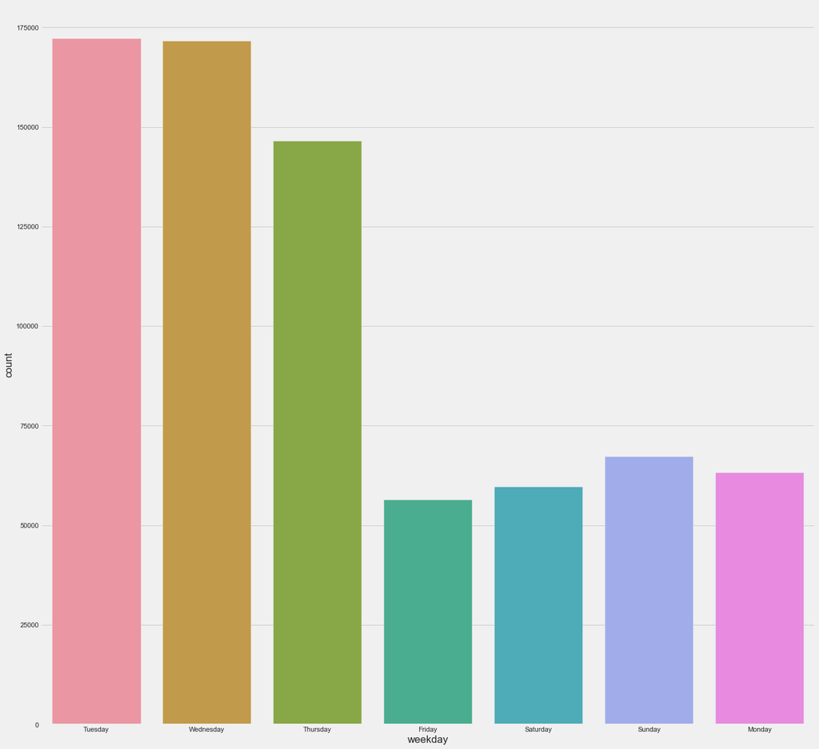

```python
sns.countplot(new_train["weekday"])
plt.show()
```

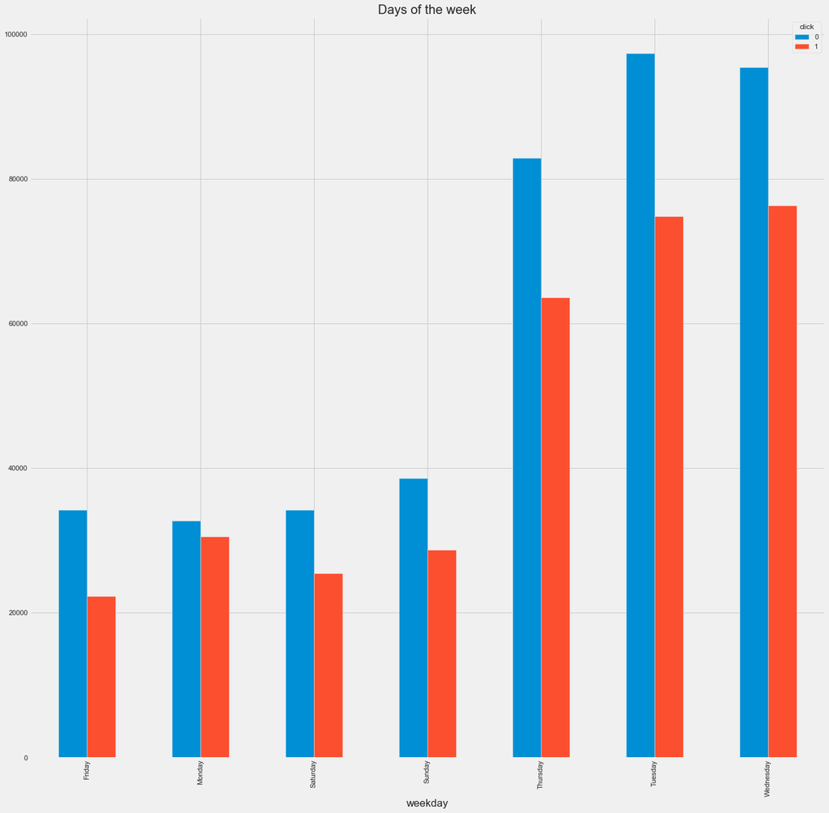

```python
new_train.groupby(['weekday','click']).size().unstack().plot(kind='bar')
plt.title('Days of the week')
```

**Click**

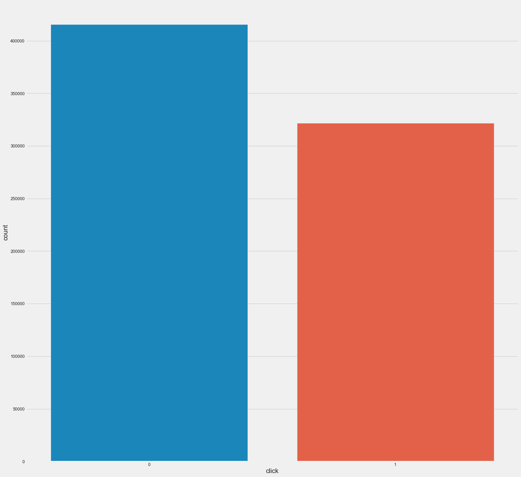

```
0    0.563473
1    0.436527
Name: click, dtype: float64
```

```python
sns.countplot(x='click',data=new_train)
plt.show()
print(new_train.click.value_counts()/len(new_train))
```

```python
# This is the global click mean
global_mean = new_train.click.mean()
global_mean
```

```
0.4365272287770721
```

Nearly 44% is the CTR of the data provided.

```python
# Calculate a mapping: {device_type: click_mean}
mean_device_type = new_train.groupby('device_type').click.mean()
mean_device_type
```

```
device_type
0    0.790603
1    0.350952
4    0.762754
5    0.764338
Name: click, dtype: float64
```

**Banner Position**

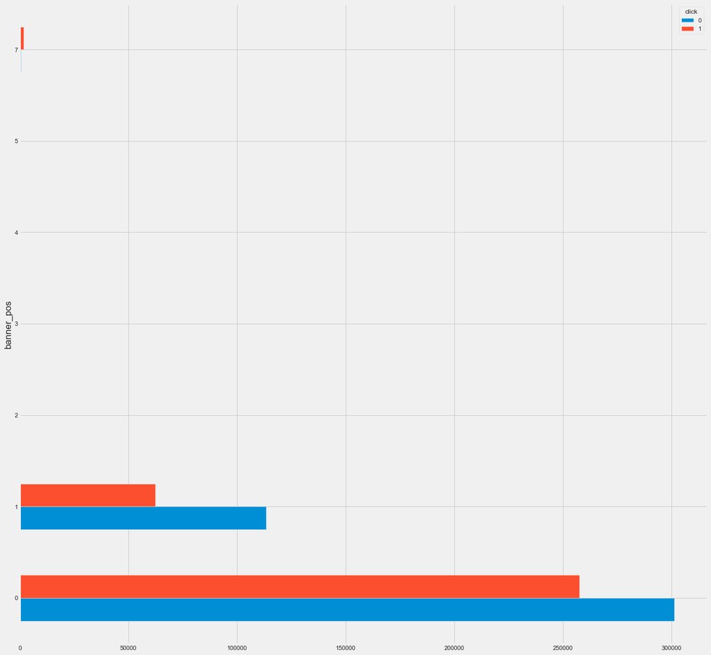

```python
new_train.groupby(['banner_pos', 'click']).size().unstack().plot(kind='barh')
plt.show()
```

**Site_features**

```python
site_features = ['site_id', 'site_domain', 'site_category']
new_train[site_features].describe()
```

|  | site_id | site_domain | site_category |
| --- | --- | --- | --- |
| count | 737198 | 737198 | 737198 |
| unique | 2280 | 2325 | 21 |
| top | 85f751fd | c4e18dd6 | 50e219e0 |
| freq | 350799 | 372703 | 441883 |

- I believe click-through rate is dependent on which site the user is on, along with which app the user seeing/using. So I want to create a new feature that represents the interaction of site_id with app_id features. This results in a cross-product between the two features.

```python
new_train['site_app'] = new_train['site_id'] + new_train['app_id']
new_train.drop(['site_id', 'app_id'], axis=1, inplace=True)
```

```python
test['site_app'] = test['site_id'] + test['app_id']
test.drop(['site_id', 'app_id'], axis=1, inplace=True)
```

**Some features have too many categories, which won't help in modeling. We also drop these columns.**

```python
new_train.nunique()
```

```
id                  500000
click                    2
hour                    10
C1                       7
banner_pos               7
site_domain           2325
site_category           21
app_domain             143
app_category            26
device_id            79066
device_ip           313616
device_model          4550
device_type              4
device_conn_type         4
C14                   2124
C15                      8
C16                      9
C17                    422
C18                      4
C19                     66
C20                    160
C21                     60
weekday                  7
site_app              4699
dtype: int64
```

```python
test.nunique()
```

```
id                  4577464
hour                     24
C1                        7
banner_pos                6
site_domain            3366
site_category            22
app_domain              201
app_category             28
device_id            291759
device_ip           1077199
device_model           5438
device_type               4
device_conn_type          4
C14                    1257
C15                       8
C16                       9
C17                     240
C18                       4
C19                      47
C20                     162
C21                      39
weekday                   1
site_app               6775
dtype: int64
```

**Conclusion**

**Drop the features with too many categories**

Train

```python
drop_list = ['id','device_id', 'device_ip']
new_train.drop(drop_list, axis=1, inplace=True)
```

```python
new_train.head().T
```

|  | 0 | 1 | 2 | 3 | 4 |
| --- | --- | --- | --- | --- | --- |
| click | 0 | 0 | 0 | 1 | 0 |
| hour | 2014-10-21 | 2014-10-21 | 2014-10-21 | 2014-10-21 | 2014-10-21 |
| C1 | 1005 | 1005 | 1010 | 1005 | 1005 |
| banner_pos | 1 | 0 | 1 | 0 | 0 |
| site_domain | d2f72222 | c7ca3108 | c4e18dd6 | 98572c79 | f7570339 |
| site_category | f028772b | 3e814130 | 50e219e0 | f028772b | f028772b |
| app_domain | 7801e8d9 | 7801e8d9 | 7801e8d9 | 7801e8d9 | 7801e8d9 |
| app_category | 07d7df22 | 07d7df22 | 0f2161f8 | 07d7df22 | 07d7df22 |
| device_model | 76dc4769 | 24f6b932 | 9f4f9b1c | 04f5b394 | a5fbe35d |
| device_type | 1 | 1 | 4 | 1 | 1 |
| device_conn_type | 0 | 0 | 0 | 0 | 0 |
| C14 | 16208 | 20362 | 21665 | 15704 | 17212 |
| C15 | 320 | 320 | 320 | 320 | 320 |
| C16 | 50 | 50 | 50 | 50 | 50 |
| C17 | 1800 | 2333 | 2493 | 1722 | 1887 |
| C18 | 3 | 0 | 3 | 0 | 3 |
| C19 | 167 | 39 | 35 | 35 | 39 |
| C20 | 100075 | -1 | -1 | 100084 | -1 |
| C21 | 23 | 157 | 117 | 79 | 23 |
| weekday | Tuesday | Tuesday | Tuesday | Tuesday | Tuesday |
| site_app | 0eb72673ecad2386 | 543a539eecad2386 | 85f751fd8c0dcd5a | d9750ee7ecad2386 | d7f3460becad2386 |

```python
new_train.to_csv('./data/train/new_train.csv',
                   header=True,
                   index=False,
                   sep=',',
                   encoding='utf-8'
                   )
```

Test

```python
test.drop(drop_list, axis=1, inplace=True)
```

```python
test.head()
```

|  | hour | C1 | banner_pos | site_domain | site_category | app_domain | app_category | device_model | device_type | device_conn_type | C14 | C15 | C16 | C17 | C18 | C19 | C20 | C21 | weekday | site_app |
| --- | --- | --- | --- | --- | --- | --- | --- | --- | --- | --- | --- | --- | --- | --- | --- | --- | --- | --- | --- | --- |
| 0 | 2014-10-31 | 1005 | 0 | f6ebf28e | f028772b | 7801e8d9 | 07d7df22 | 0eb711ec | 1 | 0 | 8330 | 320 | 50 | 761 | 3 | 175 | 100075 | 23 | Friday | 235ba823ecad2386 |
| 1 | 2014-10-31 | 1005 | 0 | f3845767 | 28905ebd | 7801e8d9 | 07d7df22 | ecb851b2 | 1 | 0 | 22676 | 320 | 50 | 2616 | 0 | 35 | 100083 | 51 | Friday | 1fbe01feecad2386 |
| 2 | 2014-10-31 | 1005 | 0 | f3845767 | 28905ebd | 7801e8d9 | 07d7df22 | 1f0bc64f | 1 | 0 | 22676 | 320 | 50 | 2616 | 0 | 35 | 100083 | 51 | Friday | 1fbe01feecad2386 |
| 3 | 2014-10-31 | 1005 | 0 | c4e18dd6 | 50e219e0 | aefc06bd | 0f2161f8 | 542422a7 | 1 | 0 | 18648 | 320 | 50 | 1092 | 3 | 809 | 100156 | 61 | Friday | 85f751fd51cedd4e |
| 4 | 2014-10-31 | 1005 | 0 | c4e18dd6 | 50e219e0 | 2347f47a | f95efa07 | 1f0bc64f | 1 | 0 | 23160 | 320 | 50 | 2667 | 0 | 47 | -1 | 221 | Friday | 85f751fd9c13b419 |

```python
test.to_csv('./data/train/new_test.csv',
                   header=True,
                   index=False,
                   sep=',',
                   encoding='utf-8'
                   )
```

**Shuffle data**

```python
new_train = new_train.sample(frac = 1)
new_train.reset_index(drop=True)
new_train.head()
```

[output not shown]